# week-41_stranger-things-dialogue

Francesco Grassi

2022-10-21

# Aim

Text mining and sentiment analysis on the tidytuesday datasets from **week 42: Stranger Things Dialogue**.

I would have **loved** to focus the analysis on individual character. However, the way the data-set is organized doesn’t seem to allow to do that easily (or at least I couldn’t figure out a way).  
So, for the moment, this is the plan (might grow while exploring the data)

- Prepare the data
- Some text mining:
  - How many words are spoken in every episode?
  - How much of each episode consists of dialogue?
  - Plot distribution of dialogue moments in each episode
- Sentiment analysis:
  - Visualize the lexicon categories of each season
  - Which are the most common positive and negative words in the series?
  - What’s the sentiment of the episodes across the seasons?

# Libraries and fonts

```r
library(tidytuesdayR)
library(tidyverse)
library(tidytext)
library(stringr)
library(lubridate)
library(colorspace)  # modify colors
library(scales)  # custom axis scales
library(showtext)  # customize font in plots
library(shadowtext)  # add outline to text
library(ggfx)  # add glow to text

# Add font to use in plots:
sysfonts::font_add(family = "Libre Baskerville",
                   regular = "LibreBaskerville-Regular.ttf",
                   italic = "LibreBaskerville-Italic.ttf",
                   bold = "LibreBaskerville-Bold.ttf")

showtext_auto()
# NOTE: when "showtext()" is enabled, it messes up with the font size in imgs SAVED VIA "GGSAVE()". I couldn't figure out how the "showtext_auto(FALSE)" before "ggsave()" works when multiple plots are saved. So the solution I'm using at the moment might not be the correct one
```

# Load data

Load data from week 42:

```r
# tuesdata <- tidytuesdayR::tt_load(2022, week = 42)  # Load datasets
# episodes <- tuesdata$episodes
# dialogue <- tuesdata$stranger_things_all_dialogue
# write_csv(episodes, file = "data/episodes.csv")
# write_csv(dialogue, file = "data/dialogue.csv")
episodes <- read_csv(file = "data/episodes.csv")
dialogue <- read_csv(file = "data/dialogue.csv")
```

# Settings

Before we start, let’s define some common variables and settings that will recur across the analysis.

First we can define a nice color palette to use in the plots. I’m using a palette created by [Adam McCoid on Adobe Color](https://color.adobe.com/search?q=stranger%20things).  
I’m going to use the four reds in the palette for the four seasons of the series, and the last “black” for plot backgrounds.  
I’m also using another red for the “glow” of plot titles. HT to [Ansgar Wolsing](https://github.com/bydata/tidytuesday/tree/main/2022/42). I’m copying the approach (and same color) with “textshadow” and “ggfx” they used for the same tidytuesday challenge! Unfortunately, I didn’t seem to make it with with faceted plots.

```r
seasons_palette <- c("#BF2C2C", "#8C262E", "#731F1F", "#401D23")
color_background <- "#0D0506"
color_title <- "#B1281E"
```

Let’s also define some settings to keep plots coherent:

```r
# Settings for plot text:
title_size <- 40
title_sigma <- 3  # SD of the gaussian blur used for title glow with "ggfx::with_inner_glow"
title_expand <- 0  # dilation of title glow for "ggfx::with_inner_glow"
axis_title_size <- 25
axis_label_size <- 15
legend_title_size <- 25
legend_text_size <- 15
strip_size <- 25  # text size for facet labels

# Settings for output images:
figure_width <- 15
figure_height <- 12
figure_unit <- "in"
figure_dpi <- 300
```

# Refine data.frames

Before starting, it would be nice to make some changes to the two data.frames. This will help making our plots prettier (and easier to prepare)! What we want to do:

- Add “Season” in front of season number
- Turn “episode” into factor (to plot it as discrete variable)
- Add a new-line character after the “Chapter X:” part of episode title and factorize it (otherwise titles are too long to plot in a single line)

```r
dialogue <- dialogue %>%
  mutate(season = paste("Season", season),
         episode = as.factor(episode))

episodes <- episodes %>%
  mutate(season = paste("Season", season),
         episode = as.factor(episode),
         title = str_replace(title, pattern = ": ", replacement = ":\n"),
         title = factor(title, levels = unique(title)))
```

# Part 1: Text mining

Let’s start with some text mining.  
First of all we have to prepare our data. What we want to do is to extract only the dialogue parts, cleaning out all the music, noises, etc. (these are rows that contain a NA in “dialogue”).  
We must be aware that there are some non-dialogue lines that contain a single white space instead of a NA. Therefore we should also filter them out.

```r
dialogue_clean <- dialogue %>%
  select(season, episode, line, dialogue, start_time, end_time) %>%  # select variables of interest
  mutate(dialogue = na_if(dialogue, " ")) %>%  # convert single white spaces in NAs
  drop_na(dialogue)  # remove non-dialogue lines
```

Let’s also add the episode titles, which are stored in the “episodes” data.frame.  
NOTE: I’m going to use a left_join to merge the episode title to the new data.frame. This is to keep the approach general, although in this specific case I could also just copy the column from “episodes”, since it has the raw order by season and episode.

```r
dialogue_clean <- dialogue_clean %>%
  left_join(y = episodes %>% select(season, episode, title),  # subset "episodes" df since we don't want to join all columns
            by = c("season", "episode"))
```

Finally, we can “tokenize” our data-set, meaning (in this case) to split each line in individual words. Since we might still need the original “un-tokenized” version of our lines, let’s create another data.frame:

```r
dialogue_token <- dialogue_clean %>%
  unnest_tokens(word, dialogue)  # tokenize "dialogue" and save single token in "word"
```

Now we can start answering some question!

## How many words are spoken in every episode?

We can visualize the answer by creating a barplot, indicating the number of words per episode. We can also divide the plot by seasons.  
I first tried to add episode title as axis labels, but the titles are too long and can’t find a way to make it nice.  
So and alternative solution is to get rid of the episode axis labels and add the episode title INSIDE the bar

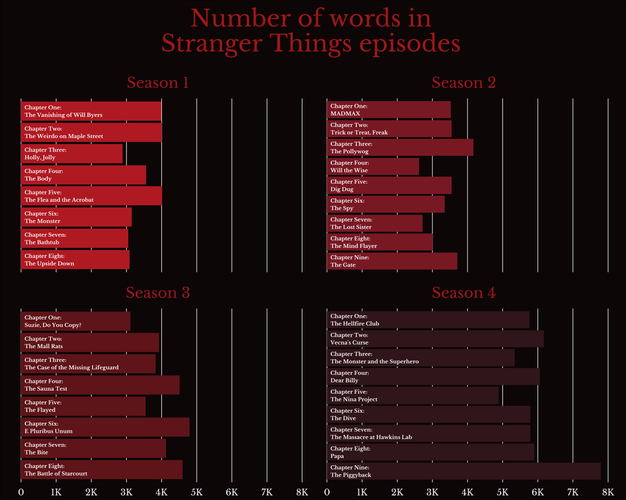

```r
# Prepare data.frame for plotting
p <- dialogue_token %>%
  group_by(season, episode, title) %>%  # group first by "season" since episodes are numbered within seasons (add "title_short" to keep it in summary data.frame)
  summarise(n_words = n()) %>%   # count words
  ungroup()

# Prepare the plot:
p %>% ggplot(aes(x = fct_rev(episode), y = n_words, fill = season)) +  # x is reversed so that after "coord_flip" episodes are listed top-down
  geom_col() +  # add bars
  geom_text(  # add titles inside bars
    aes(y = 100, hjust = 0, label = title),  # "y = 100" to add some padding from the x-axis
    size = 9/.pt,  # ("/.pt" scales the text size unit of "geom_text" to the one of "element_text()")
    color = "white",
    family = "Libre Baskerville",
    fontface = "bold") +
  coord_flip() +
  facet_wrap(~ season, scales = "free_y") +  # unlike "labs", this refers to coord AFTER flip
  labs(title = "Number of words in\nStranger Things episodes",
       x = "Episode",
       y = "Number of words") +
  scale_y_continuous(breaks = c(0, seq(1000, 8000, by = 1000)), labels = label_number(scale_cut = cut_short_scale())) +
  scale_fill_manual(values = seasons_palette) +
  theme_minimal() +
  theme(text = element_text(family = "Libre Baskerville"),  # font family for entire plot
        plot.title = element_text(size = title_size, color = color_title, hjust = 0.5, margin = margin(0, 0, 30, 0)),  # size, color, and margin of main title
        plot.background = element_rect(fill = color_background),  # background of entire plotting area
        plot.margin = margin(15, 20, 10, 10),  # adjust margins of plotting area
        panel.grid.major.y = element_blank(),  # remove major grid for y axis
        panel.grid.minor = element_blank(),  # remove minor grid for both axis
        panel.spacing.y = unit(1.5, "lines"),  # change spacing between facets
        axis.title = element_blank(),  # remove axis title
        axis.text.x = element_text(size = axis_label_size, hjust = 0.5, vjust = -0.5, color = "white"),  # size, just, and color of x-axis labels
        axis.text.y = element_blank(),  # remove y-axis label
        legend.position = "none",  # remove legend
        strip.text.x = element_text(size = strip_size, color = color_title, margin = margin(0, 0, 15, 0))  # size, color, and margin of facet titles
        )
```

```r
showtext_auto(FALSE)
ggsave(file = "img/words-per-episode.png", dpi = 300, width = 15, height = 12, units = "in" )
```

## How much of each episode consists of dialogue?

For this question we can think of a **pyramid plot**.  
We can plot each episode as a bar, all with the same length, indicating the total (100%) episode duration. The left side of each bar will represent the percentage of the episode consisting of dialogue, and the right the non-dialogue part.  
If we want to add episode titles to this plot too, it will be better to add them as a separate text element on one side of the figure.

The plan requires some data preparation, using most of the data-frames created so far.  
NOTE: in this section we’ll need to work a lot with dates and durations. I’m still not very familiar with this type of data, so some of the following steps might be unnecessary or not the most efficient ones. Still learning :)

First, we need to calculate the total duration of the dialogue in each episode. We can do that from the “dialogue_clean” data.frame, by calculating the time duration between “start_time” and “end_time”. Then, we can sum up all the duration within each episode:

```r
dialogue_time <- dialogue_clean %>%
  mutate(start_time = hms(start_time),  # convert "start_time" to use with "lubridate"
         end_time = hms(end_time)) %>%  # same for "end_time
  mutate(duration_dialogue = as.duration(end_time - start_time)) %>%  # calculate duration
  group_by(season, episode, title) %>%
  summarize(duration_dialogue = sum(duration_dialogue))  # sum dialog duration by episode
```

Now, we also need to find the total duration of each episode, in order to then calculate the percentage consisting in dialogue.  
We can find this, by extracting the “end_time” value from the last line of each episode in the original “dialogue” data.frame (or at least this is the only indicator of the time of the episode’s ending that we have at hand).

```r
episode_duration_df <- dialogue %>%
  group_by(season, episode) %>%
  filter(row_number() == n())  # extract last row per episode
```

And now we can add the “end_time” from “episode_duration_df” to “dialogue_time” and convert it to numeric

```r
dialogue_time <- dialogue_time %>%
  left_join(y = episode_duration_df %>%
              select(season, episode, end_time),  # from "dialogue", select only variables of interest
            by = c("season", "episode")) %>%
  mutate(end_time = as.numeric(end_time)) %>%
  rename(duration_total = end_time)  # also rename variable to keep it consistent
```

Let’s then calculate the percentage of the episode consisting in dialogue and non-dialogue.  
NOTE: we make the dialogue duration negative, which will help plotting it

```r
dialogue_time <- dialogue_time %>%
  mutate(perc_dialogue = -round(duration_dialogue/duration_total, 3),
         perc_no_dialogue = 1 + perc_dialogue)
```

And now we can convert the data.frame to long, pivoting by the two dialogue proportions variables:

```r
dialogue_time_long <- dialogue_time %>%
  pivot_longer(col = c(perc_dialogue, perc_no_dialogue), values_to = "percentage", names_to = "dialogue") %>%
  mutate(dialogue = fct_recode(dialogue, dialogue = "perc_dialogue", no_dialogue = "perc_no_dialogue"))  # also factorize and recode the new variable
```

The idea is to have a pyramid plot, with dialogue portion on the left and non-dialogue on the right. We might want to add the percentages inside the bars. To facilitate this, we can create a new variable, providing a different x-coordinate for positive (non-dialogue) and negative (dialogue) percentages.  
Moreover, I’m also going to create a new variable, providing the episode number ACROSS the entire series. We will use this variable to plot all the episode’s data one under the other.  
Lastly, we also want to display the episode titles. However, this time would be better to plot them in a single line, so let’s remove the new-line character we added before.

```r
dialogue_time_long <- dialogue_time_long %>%
  mutate(x_coord = case_when(  # add x-coord
    percentage < 0 ~ -0.053,  # slightly different values to compensate for left/right just
    percentage > 0 ~ 0.055)) %>%
  group_by(dialogue) %>%  # repeat episode number for the two dialogue conditions
  mutate(total_episode = as.factor(row_number())) %>%  # calculate total episode number
  mutate(title = str_replace(title, pattern = ":\n", replacement = ": "))  # remove new-line character
```

Finally, let’s prepare a more complex palette for this plot. We are going to have two coloring factors, the dialogue/non-dialogue proportion, and the season. In order to manually define the colors to use, we must define a vector of colors made from the four colors for the seasons, which we will use for the “dialogue” part of the plot, followed by the same colors but desaturated, to use for the “non-dialogue” part.

```r
season_dialogue_palette <- c(seasons_palette, desaturate(seasons_palette, 0.7))  # Define color palette
```

And now let’s plot!

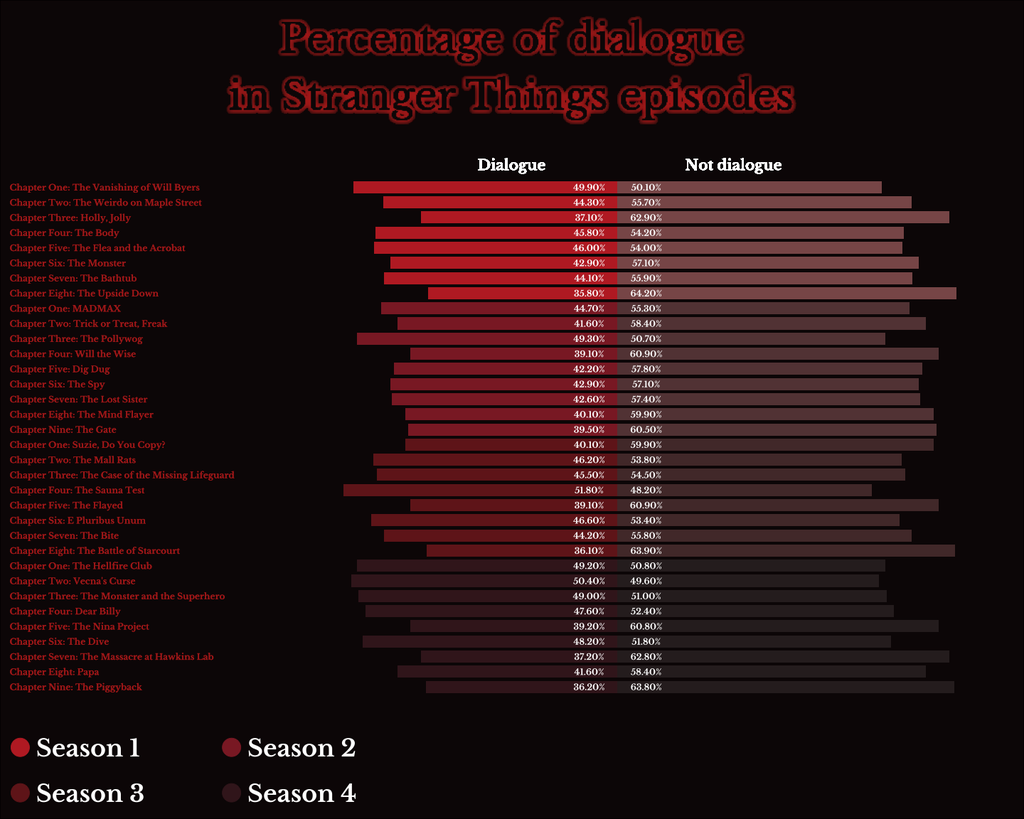

```r
dialogue_time_long %>%
  ggplot(aes(x = percentage, y = fct_rev(total_episode), fill = interaction(season, dialogue))) +  # x is reversed so that after "coord_flip" episodes are listed top-down
  geom_col(width = 0.8) +
  with_inner_glow(  # Add glow to title
    geom_shadowtext(  # Add outline to title
      data = NULL,
      aes(x = -0.2, y = 42, label = "Percentage of dialogue\nin Stranger Things episodes"),
      family = "Libre Baskerville", color = color_background, bg.color = color_title, size = (title_size+2)/.pt,
      inherit.aes = FALSE, lineheight = 1.2),
    sigma = title_sigma, expand = title_expand, color = color_title
    ) +
  geom_text(  # add episode titles
    aes(x = -1.15, y = fct_rev(total_episode), hjust = 0, label = title),  # "y = 100" to add some padding from the x-axis
    size = 9/.pt,  # ("/.pt" scales the text size unit of "geom_text" to the one of "element_text()")
    color = color_title,
    family = "Libre Baskerville",
    fontface = "bold") +
  geom_text(  # add percentages inside bars
    aes(x = x_coord, y = fct_rev(total_episode), label = percent(abs(percentage))),  # turn "percentage" into character with "%" sign
    size = 9/.pt,
    color = "white",
    family = "Libre Baskerville",
    fontface = "bold") +
  # Add season names:
  annotate("text", x = -1.1, y = -3, label = "Season 1", hjust = 0, size = axis_title_size/.pt, color = "white", family = "Libre Baskerville", fontface = "bold") +
  annotate("text", x = -0.7, y = -3, label = "Season 2", hjust = 0, size = axis_title_size/.pt, color = "white", family = "Libre Baskerville", fontface = "bold") +
  annotate("text", x = -1.1, y = -6, label = "Season 3", hjust = 0, size = axis_title_size/.pt, color = "white", family = "Libre Baskerville", fontface = "bold") +
  annotate("text", x = -0.7, y = -6, label = "Season 4", hjust = 0, size = axis_title_size/.pt, color = "white", family = "Libre Baskerville", fontface = "bold") +
  # Add season color:
  annotate("point", x = -1.13, y = -3, size = axis_title_size/.pt, color = seasons_palette[1]) +
  annotate("point", x = -0.73, y = -3, size = axis_title_size/.pt, color = seasons_palette[2]) +
  annotate("point", x = -1.13, y = -6, size = axis_title_size/.pt, color = seasons_palette[3]) +
  annotate("point", x = -0.73, y = -6, size = axis_title_size/.pt, color = seasons_palette[4]) +
  geom_text(  # add "Dialogue" text
    aes(x = -0.2, y = 35.5, label = "Dialogue"), size = axis_label_size/.pt, color = "white", family = "Libre Baskerville", fontface = "bold") +
  geom_text(  # add "Not Dialogue" text
    aes(x = 0.22, y = 35.5, label = "Not dialogue"), size = axis_label_size/.pt, color = "white", family = "Libre Baskerville", fontface = "bold") +
  coord_cartesian(xlim = c(-0.7, 0.7),
                  clip = "off") +  # make drawing not clipped to the plot panel (allows to add "geom_text" outside plot area)
  scale_x_continuous(breaks = seq(-0.7, 0.7, by = 0.1), labels = percent_format(scale = 1)) +
  scale_fill_manual(values = season_dialogue_palette) +
  theme_minimal() +
  theme(text = element_text(family = "Libre Baskerville"),  # font family for entire plot
        plot.background = element_rect(fill = color_background),  # background of entire plotting area
        plot.margin = margin(70, 0, 25, 220),  # adjust margins of plotting area
        panel.grid.major = element_blank(),
        panel.grid.minor = element_blank(),
        axis.title = element_blank(),
        axis.text = element_blank(),
        legend.position = "none")
```

```r
showtext_auto(FALSE)
ggsave(file = "img/percentage-dialogue.png", dpi = 300, width = 15, height = 12, units = "in" )
```